# Question 1

# Question 3

```python
# 3.1-Read iris.csv as a dataframe. Report number of instances and features.
dfIris = pd.read_csv('./iris.csv')
dfIris.info()
```

```
<class 'pandas.core.frame.DataFrame'>
RangeIndex: 150 entries, 0 to 149
Data columns (total 5 columns):
 #   Column        Non-Null Count  Dtype
---  ------        --------------  -----
 0   Sepal Length  150 non-null    float64
 1   Sepal Width   150 non-null    float64
 2   Petal Length  150 non-null    float64
 3   Petal Width   150 non-null    float64
 4   Class         150 non-null    object
dtypes: float64(4), object(1)
memory usage: 6.0+ KB
```

```python
#There are 150 instances and 4 features
```

```python
# 3.2 - Selected the features for clustering (without the Classes).
dfKMeans = dfIris.iloc[:,0:-1]
dfLabels = dfIris.iloc[:,-1:]
dfLabels.head()
```

|  | Class |
| --- | --- |
| 0 | Iris-versicolor |
| 1 | Iris-versicolor |
| 2 | Iris-versicolor |
| 3 | Iris-setosa |
| 4 | Iris-versicolor |

```python
# 3.3 -  Using scikit-learn library to perform K-means clustering.
kmeans = KMeans(n_clusters=3).fit(df_Kmeans)
dfKMeans['Labels'] = kmeans.labels_
dfLabels['kmeans'] = kmeans.labels_
```

[figure not shown]

```python
# 3.4 - Plot the clustering result. (x-axis is Sepal Length and y-axis is Sepal Width)
sns.scatterplot(data=dfKMeans, x="Sepal Length", y="Sepal Width",hue='Labels')
plt.show()
```

```python
# 3.5 - Using scikit-learn library to perform DBSCAN clustering.
dfDBSCAN = dfIris.iloc[:,0:-1]
dbscan = DBSCAN().fit(dfDBSCAN)
dfDBSCAN['Labels'] = dbscan.labels_
dfLabels['dbscan'] = dbscan.labels_
```

[output not shown]

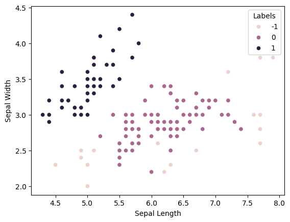

```python
# 3.6 - Plot the clustering result. (x-axis is Sepal Length and y-axis is Sepal Width)
sns.scatterplot(data=dfDBSCAN, x="Sepal Length", y="Sepal Width",hue='Labels')
plt.plot()
```

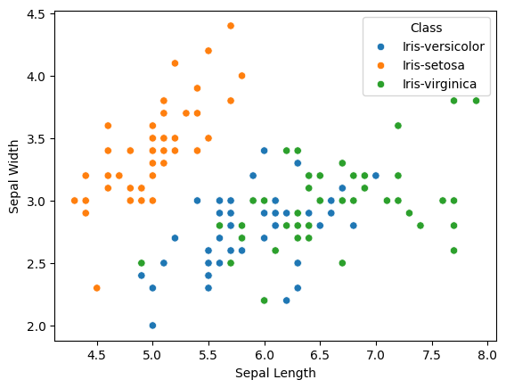

```python
# 3.7 - According to your result, which clustering method do you think is better for iris
#dataset? Why?
sns.scatterplot(data=dfIris, x="Sepal Length", y="Sepal Width",hue='Class')
plt.show()
```

```python
pd.crosstab(dfLabels.Class,dfLabels.kmeans)
```

[output not shown]

```python
pd.crosstab(dfLabels.Class,dfLabels.dbscan)
```

| dbscan Class | -1 | 0 | 1 |
| --- | --- | --- | --- |
| Iris-setosa | 1 | 0 | 49 |
| Iris-versicolor | 6 | 44 | 0 |
| Iris-virginica | 10 | 40 | 0 |

Looking at both the plots of the results and at the crosstabs, one can see that k-means is the better method of the two. In the DBSCAN model one can see that a single label dominates the roughly trapezoid-shaped area between sepal length 5.5 and 7.5 whereas the area should have a mix of versicolor and virginica. The crosstab confirms there is plenty of mislabeling with DBSCAN(one label only has 17 instances, versus the even 50-50-50 of the dataset). K-means in turn looks better considering the plot and crosstab.

Why does DBSCAN performs worse? It is not clear from the original plot that a density-based clustering would be better. The intermixing of versicolor and virginica throws off a method dependent on density of points.